# Data Science for Business: Homework Assignment

##### **Emp.var.rate** (*numeric*)

Employment variation rate (quarterly). To be honest, I’m not so familiar with this indicator. Let’s have a look at it. Wow! We have negative values. So, according to Google search, I found that it’s a kind of macroeconomic indicator that’s related to the contact date (with quartely data collection). I’m not sure it will be relevant for us, but we’ll see. Some relationship, however, is presumable with the contact date.

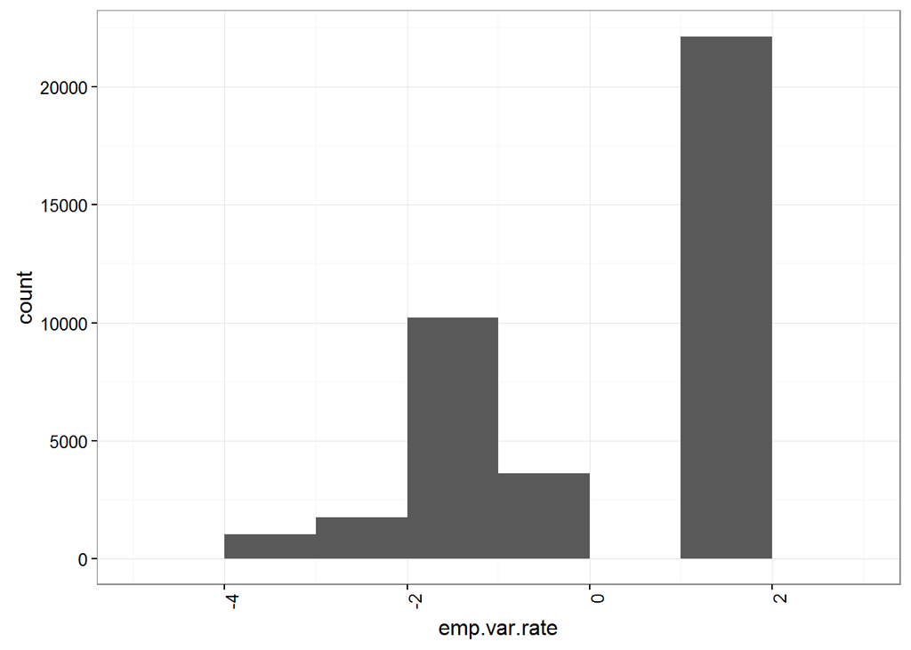

```r
ggplot(bank, aes(x = emp.var.rate)) + geom_histogram(binwidth = 1) + theme_bw() + theme(axis.text.x = element_text(angle = 90, hjust = 1))
```

##### **Cons.price.idx** (*numeric*)

Consumer price index, also a macro indicator, collected on monthly basis.

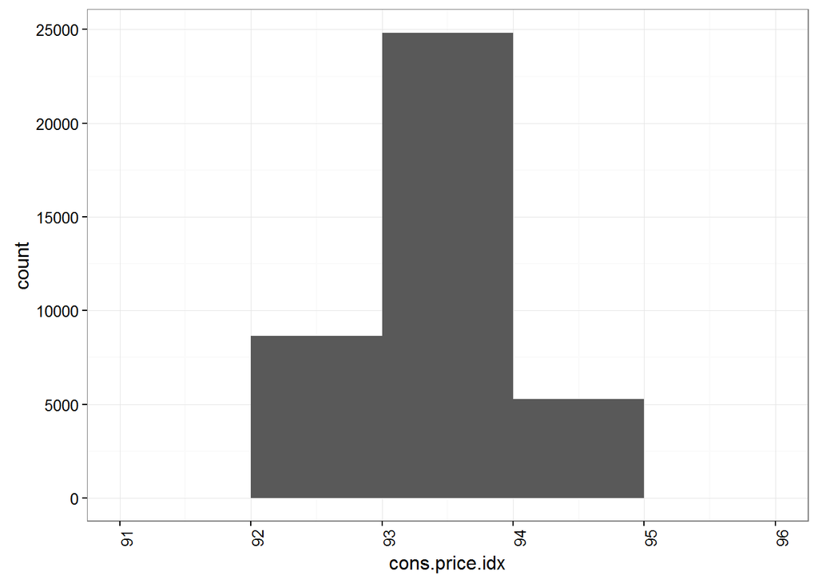

```r
ggplot(bank, aes(x = cons.price.idx)) + geom_histogram(binwidth = 1) + theme_bw() + theme(axis.text.x = element_text(angle = 90, hjust = 1))
```

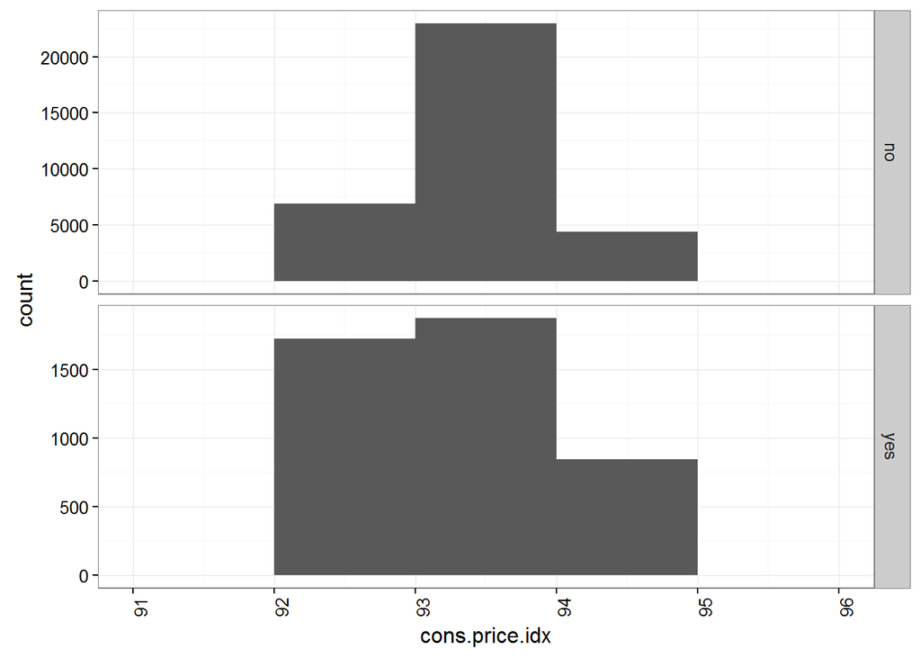

```r
ggplot(bank) + geom_histogram(aes(x = cons.price.idx), binwidth = 1) +
  facet_grid(y~., scales = "free")  + theme_bw() + theme(axis.text.x = element_text(angle = 90, hjust = 1))
```

##### **Cons.conf.idx** (*numeric*)

Consumer confidence index, also a macro indicator, collected on monthly basis (also with some values that are smaller than 0)

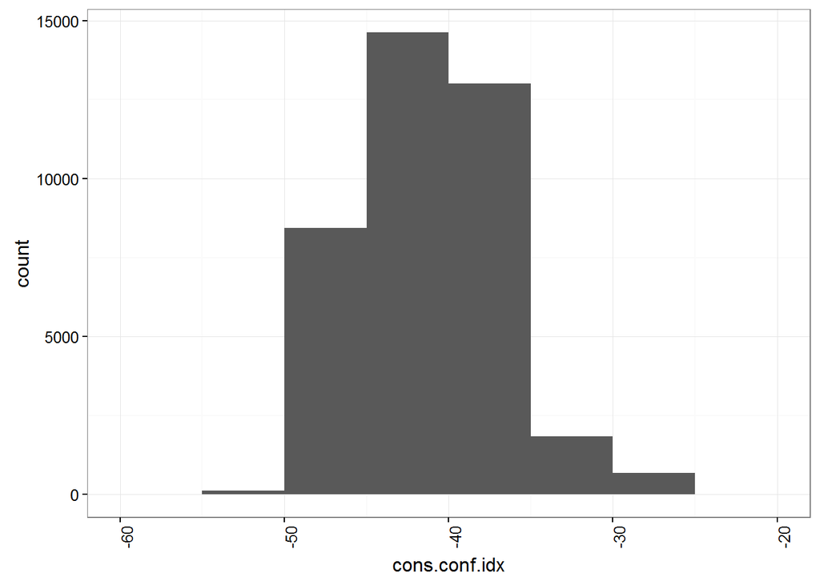

```r
ggplot(bank, aes(x = cons.conf.idx)) + geom_histogram(binwidth = 5) + theme_bw() + theme(axis.text.x = element_text(angle = 90, hjust = 1))
```

##### **euribor3m** (*numeric*)

euribor3m: 3m Euro Interbank Offered Rates (based on avg. interest rates) on a daily basis.

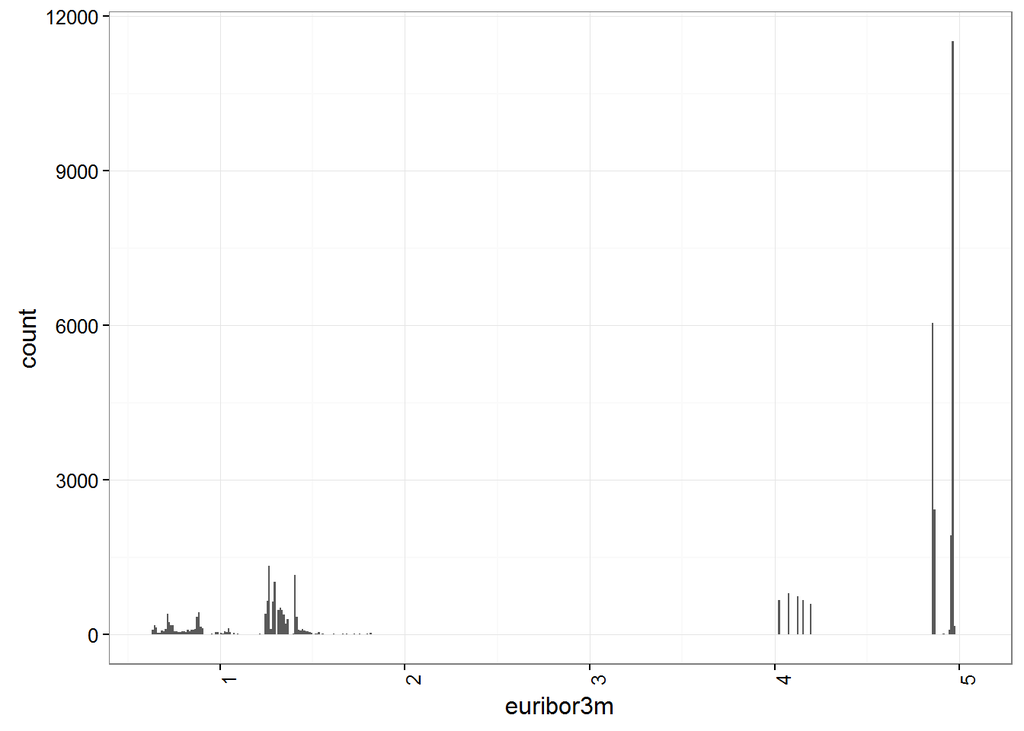

```r
ggplot(bank, aes(x = euribor3m)) + geom_histogram(binwidth = 0.01) + theme_bw() + theme(axis.text.x = element_text(angle = 90, hjust = 1))
```

##### **Nr.employed** (*numeric*)

Number of employees collected on a quarterly base.

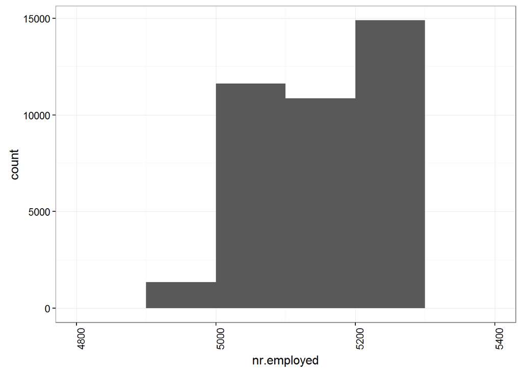

```r
ggplot(bank, aes(x = nr.employed)) + geom_histogram(binwidth = 100) + theme_bw() + theme(axis.text.x = element_text(angle = 90, hjust = 1))
```

After above modifications we have 38717 observations (excluded 2471).

```r
dim(bank)
```

```
## [1] 38717    22
```

#### Data cleaning and feature engineering

Data cleaning was performed above, here comes some new features derived from the feature set shown previously and some to drop out of our prediction.

##### A new feature: age group

```r
bank$age_1 <- as.numeric(bank$age < 30)
bank$age_2 <- as.numeric(bank$age >= 30 & bank$age <= 60)
bank$age_3 <- as.numeric(bank$age > 60)
```

##### New variables: numeric values for categorical variables

In order to provide available all categorical variables for the modeling stage I also decided to add some new variables.

###### For Job categories

```r
bank$job_1 <- as.numeric(bank$job == "admin")
bank$job_2 <- as.numeric(bank$job == "blue_collar")
bank$job_3 <- as.numeric(bank$job == "entrepreneur")
bank$job_4 <- as.numeric(bank$job == "housemaid")
bank$job_5 <- as.numeric(bank$job == "management")
bank$job_6 <- as.numeric(bank$job == "retired")
bank$job_7 <- as.numeric(bank$job == "self-employed")
bank$job_8 <- as.numeric(bank$job == "services")
bank$job_9 <- as.numeric(bank$job == "student")
bank$job_10 <- as.numeric(bank$job == "technician")
bank$job_11 <- as.numeric(bank$job == "unemployed")
```

###### For Marital status

```r
bank$marital_1 <- as.numeric(bank$marital == "single")
bank$marital_2 <- as.numeric(bank$marital == "married")
bank$marital_3 <- as.numeric(bank$marital == "divorced")
```

###### For Education

```r
bank$edu_1 <- as.numeric(bank$education == "basic.4y")
bank$edu_2 <- as.numeric(bank$education == "basic.6y")
bank$edu_3 <- as.numeric(bank$education == "basic.9y")
bank$edu_4 <- as.numeric(bank$education == "high.school")
bank$edu_5 <- as.numeric(bank$education == "professional.course")
bank$edu_6 <- as.numeric(bank$education == "university.degree")
bank$edu_7 <- as.numeric(bank$education == "unknown")
```

###### For Default

```r
bank$default_1 <- as.numeric(bank$default == "no")
bank$default_2 <- as.numeric(bank$default == "unknown")
```

###### For Housing

```r
bank$housing_1 <- as.numeric(bank$housing == "no")
bank$housing_2 <- as.numeric(bank$housing == "yes")
```

###### For Loan

```r
bank$loan_1 <- as.numeric(bank$loan == "no")
bank$loan_2 <- as.numeric(bank$loan == "yes")
```

###### For Contact

```r
bank$con_1 <- as.numeric(bank$contact == "cellular")
bank$con_2 <- as.numeric(bank$contact == "telephone")
```

###### For Month

```r
bank$mar <- as.numeric(bank$month == "mar")
bank$apr <- as.numeric(bank$month  == "apr")
bank$may <- as.numeric(bank$month  == "may")
bank$jun <- as.numeric(bank$month  == "jun")
bank$jul <- as.numeric(bank$month  == "jul")
bank$aug <- as.numeric(bank$month  == "aug")
bank$sep <- as.numeric(bank$month  == "sep")
bank$oct <- as.numeric(bank$month  == "oct")
bank$nov <- as.numeric(bank$month  == "nov")
bank$dec <- as.numeric(bank$month  == "dec")
```

###### For Day of week

```r
bank$mon <- as.numeric(bank$day_of_week == "mon")
bank$tue <- as.numeric(bank$day_of_week  == "tue")
bank$wed <- as.numeric(bank$day_of_week  == "wed")
bank$thu <- as.numeric(bank$day_of_week  == "thu")
bank$fri <- as.numeric(bank$day_of_week  == "fri")
```

###### For Poutcome

```r
bank$poutcome1  <- as.numeric(bank$poutcome == "failure")
bank$poutcome2  <- as.numeric(bank$poutcome == "nonexistent")
bank$poutcome3  <- as.numeric(bank$poutcome == "success")
```

#### Some modicitaions of feature names

```r
bank <- bank %>% rename(empvarrate = `emp.var.rate`, conspriceidx  = `cons.price.idx`, consconfidx  = `cons.conf.idx`, nremployed  = `nr.employed`)
```

#### Drop some features

Now we have several features and some of them are overrepresented due to the dummification. There are also some features that seem to be not so good preictors or simply irrelevant as they are. So let’s drop out, which we don’t want to use at the modeling phase.

```r
bank$job <- NULL # Drop originals od dummified categorical features
bank$marital <- NULL
bank$education <- NULL
bank$default <- NULL
bank$housing <- NULL
bank$loan <- NULL
bank$contact <- NULL
bank$month <- NULL
bank$day_of_week <- NULL
bank$poutcome <- NULL


bank$duration <- NULL
bank$pdays <- NULL

bank$empvarrate <- NULL
bank$conspriceidx <- NULL
bank$consconfidx <- NULL
bank$euribor3m <- NULL
bank$nremployed <- NULL

bank <- bank[,c(4,1,2,3,5:55)] #Reorder variables to put target variable to the first place
```

After such steps we get many new variables containing binary values and some droped.

```r
colnames(bank)
```

```
##  [1] "y"         "age"       "campaign"  "previous"  "lnage"
##  [6] "age_1"     "age_2"     "age_3"     "job_1"     "job_2"
## [11] "job_3"     "job_4"     "job_5"     "job_6"     "job_7"
## [16] "job_8"     "job_9"     "job_10"    "job_11"    "marital_1"
## [21] "marital_2" "marital_3" "edu_1"     "edu_2"     "edu_3"
## [26] "edu_4"     "edu_5"     "edu_6"     "edu_7"     "default_1"
## [31] "default_2" "housing_1" "housing_2" "loan_1"    "loan_2"
## [36] "con_1"     "con_2"     "mar"       "apr"       "may"
## [41] "jun"       "jul"       "aug"       "sep"       "oct"
## [46] "nov"       "dec"       "mon"       "tue"       "wed"
## [51] "thu"       "fri"       "poutcome1" "poutcome2" "poutcome3"
```

```r
dim(bank)
```

```
## [1] 38717    55
```

#### Split sample

Here I’m going to split the entire sample into training/validation/test sets and also provide possibilites for cross-validation.

```r
set.seed(41)

N <- nrow(bank)
idx_train <- sample(1:N,N/2)
idx_valid <- sample(base::setdiff(1:N, idx_train), N/4)
idx_test <- base::setdiff(base::setdiff(1:N, idx_train),idx_valid)
bank_train <- bank[idx_train,]
bank_valid <- bank[idx_valid,]
bank_test  <- bank[idx_test,]
```

### Modeling

#### Setup H2O

```r
library(h2o)
h2o.init(max_mem_size = "4g", nthreads = -1)
```

```
## Successfully connected to http://127.0.0.1:54321/
##
## R is connected to the H2O cluster:
##     H2O cluster uptime:         6 hours 40 minutes
##     H2O cluster version:        3.6.0.8
##     H2O cluster name:           H2O_started_from_R_Szaffi_bmy941
##     H2O cluster total nodes:    1
##     H2O cluster total memory:   3.56 GB
##     H2O cluster total cores:    4
##     H2O cluster allowed cores:  4
##     H2O cluster healthy:        TRUE
```

```
## IP Address: 127.0.0.1
## Port      : 54321
## Session ID: _sid_a8313f0799fb174036f6be8457cb4d52
## Key Count : 0
```

#### Upload sets to H2O

```r
b_train <- as.h2o(bank_train)
b_valid <- as.h2o(bank_valid)
b_test <- as.h2o(bank_test)
```

#### Run a Random Forest model

```r
system.time({
  rf <- h2o.randomForest(x = 2:ncol(b_train), y = 1,
                         seed = 41 ,training_frame = b_train, validation_frame=b_valid,
                         mtries = -1, ntrees = 500, max_depth = 20, nbins = 200)
})
```

```
##    user  system elapsed
##    1.87    0.02  121.43
```

Let’s see the results. Not so dazzling, to be honest. What about GBM?

```r
rf
```

```
## Model Details:
## ==============
##
## H2OBinomialModel: drf
## Model ID:  DRF_model_R_1456672522539_158
## Model Summary:
##   number_of_trees model_size_in_bytes min_depth max_depth mean_depth
## 1             500             8042272        20        20   20.00000
##   min_leaves max_leaves mean_leaves
## 1        967       1857  1375.47200
##
##
## H2OBinomialMetrics: drf
## ** Reported on training data. **
## Description: Metrics reported on Out-Of-Bag training samples
##
## MSE:  0.0866662
## R^2:  0.1601851
## LogLoss:  0.3053472
## AUC:  0.758401
## Gini:  0.516802
##
## Confusion Matrix for F1-optimal threshold:
##           no  yes    Error         Rate
## no     15566 1530 0.089495  =1530/17096
## yes     1170 1092 0.517241   =1170/2262
## Totals 16736 2622 0.139477  =2700/19358
##
## Maximum Metrics: Maximum metrics at their respective thresholds
##                       metric threshold    value idx
## 1                     max f1  0.214638 0.447174 206
## 2                     max f2  0.136403 0.489068 248
## 3               max f0point5  0.334447 0.468855 157
## 4               max accuracy  0.585381 0.890691  78
## 5              max precision  0.813256 0.696970  17
## 6           max absolute_MCC  0.300184 0.373386 169
## 7 max min_per_class_accuracy  0.092021 0.684350 287
##
## H2OBinomialMetrics: drf
## ** Reported on validation data. **
##
## MSE:  0.08223154
## R^2:  0.1718191
## LogLoss:  0.2924955
## AUC:  0.7618936
## Gini:  0.5237872
##
## Confusion Matrix for F1-optimal threshold:
##          no  yes    Error        Rate
## no     7959  638 0.074212   =638/8597
## yes     586  496 0.541590   =586/1082
## Totals 8545 1134 0.126459  =1224/9679
##
## Maximum Metrics: Maximum metrics at their respective thresholds
##                       metric threshold    value idx
## 1                     max f1  0.254229 0.447653 189
## 2                     max f2  0.117546 0.498814 262
## 3               max f0point5  0.478011 0.482290 112
## 4               max accuracy  0.531703 0.898440  96
## 5              max precision  0.913663 1.000000   0
## 6           max absolute_MCC  0.314110 0.381417 166
## 7 max min_per_class_accuracy  0.091405 0.687333 287
```

```r
h2o.auc(rf)
```

```
## [1] 0.758401
```

```r
h2o.auc(h2o.performance(rf, b_test))
```

```
## [1] 0.7655894
```

```r
mse <- h2o.mse(rf,train=TRUE,valid=TRUE)
print(mse)
```

```
##      train      valid
## 0.08666620 0.08223154
```

```r
err <- eval(rf,b_train,b_valid)
print(err)
```

```
## Model Details:
## ==============
##
## H2OBinomialModel: drf
## Model ID:  DRF_model_R_1456672522539_158
## Model Summary:
##   number_of_trees model_size_in_bytes min_depth max_depth mean_depth
## 1             500             8042272        20        20   20.00000
##   min_leaves max_leaves mean_leaves
## 1        967       1857  1375.47200
##
##
## H2OBinomialMetrics: drf
## ** Reported on training data. **
## Description: Metrics reported on Out-Of-Bag training samples
##
## MSE:  0.0866662
## R^2:  0.1601851
## LogLoss:  0.3053472
## AUC:  0.758401
## Gini:  0.516802
##
## Confusion Matrix for F1-optimal threshold:
##           no  yes    Error         Rate
## no     15566 1530 0.089495  =1530/17096
## yes     1170 1092 0.517241   =1170/2262
## Totals 16736 2622 0.139477  =2700/19358
##
## Maximum Metrics: Maximum metrics at their respective thresholds
##                       metric threshold    value idx
## 1                     max f1  0.214638 0.447174 206
## 2                     max f2  0.136403 0.489068 248
## 3               max f0point5  0.334447 0.468855 157
## 4               max accuracy  0.585381 0.890691  78
## 5              max precision  0.813256 0.696970  17
## 6           max absolute_MCC  0.300184 0.373386 169
## 7 max min_per_class_accuracy  0.092021 0.684350 287
##
## H2OBinomialMetrics: drf
## ** Reported on validation data. **
##
## MSE:  0.08223154
## R^2:  0.1718191
## LogLoss:  0.2924955
## AUC:  0.7618936
## Gini:  0.5237872
##
## Confusion Matrix for F1-optimal threshold:
##          no  yes    Error        Rate
## no     7959  638 0.074212   =638/8597
## yes     586  496 0.541590   =586/1082
## Totals 8545 1134 0.126459  =1224/9679
##
## Maximum Metrics: Maximum metrics at their respective thresholds
##                       metric threshold    value idx
## 1                     max f1  0.254229 0.447653 189
## 2                     max f2  0.117546 0.498814 262
## 3               max f0point5  0.478011 0.482290 112
## 4               max accuracy  0.531703 0.898440  96
## 5              max precision  0.913663 1.000000   0
## 6           max absolute_MCC  0.314110 0.381417 166
## 7 max min_per_class_accuracy  0.091405 0.687333 287
```

#### Run a GBM model

```r
system.time({
  gbm <- h2o.gbm(x = 2:ncol(b_train), y = 1,
                seed = 41, training_frame = b_train, validation_frame = b_valid,
                max_depth = 15, ntrees = 500, learn_rate = 0.03, nbins = 100,
                stopping_rounds = 3)
})
```

```
##    user  system elapsed
##    1.04    0.02   76.95
```

Now, the results. Could be better if parameter were changed.

```r
gbm
```

```
## Model Details:
## ==============
##
## H2OBinomialModel: gbm
## Model ID:  GBM_model_R_1456672522539_163
## Model Summary:
##   number_of_trees model_size_in_bytes min_depth max_depth mean_depth
## 1              96              318893        15        15   15.00000
##   min_leaves max_leaves mean_leaves
## 1        216        410   278.97916
##
##
## H2OBinomialMetrics: gbm
## ** Reported on training data. **
##
## MSE:  0.0623563
## R^2:  0.3957534
## LogLoss:  0.225379
## AUC:  0.9098249
## Gini:  0.8196498
##
## Confusion Matrix for F1-optimal threshold:
##           no  yes    Error         Rate
## no     16552  544 0.031820   =544/17096
## yes     1042 1220 0.460654   =1042/2262
## Totals 17594 1764 0.081930  =1586/19358
##
## Maximum Metrics: Maximum metrics at their respective thresholds
##                       metric threshold    value idx
## 1                     max f1  0.274668 0.606061 181
## 2                     max f2  0.108327 0.684137 263
## 3               max f0point5  0.475493 0.728742 122
## 4               max accuracy  0.475493 0.926025 122
## 5              max precision  0.926197 1.000000   0
## 6           max absolute_MCC  0.413529 0.581754 140
## 7 max min_per_class_accuracy  0.104774 0.829258 267
##
## H2OBinomialMetrics: gbm
## ** Reported on validation data. **
##
## MSE:  0.08226971
## R^2:  0.1714347
## LogLoss:  0.2910018
## AUC:  0.7611116
## Gini:  0.5222233
##
## Confusion Matrix for F1-optimal threshold:
##          no  yes    Error        Rate
## no     7956  641 0.074561   =641/8597
## yes     565  517 0.522181   =565/1082
## Totals 8521 1158 0.124600  =1206/9679
##
## Maximum Metrics: Maximum metrics at their respective thresholds
##                       metric threshold    value idx
## 1                     max f1  0.195781 0.461607 210
## 2                     max f2  0.130635 0.496259 243
## 3               max f0point5  0.402700 0.488858 135
## 4               max accuracy  0.550638 0.897097  92
## 5              max precision  0.933089 1.000000   0
## 6           max absolute_MCC  0.195781 0.391535 210
## 7 max min_per_class_accuracy  0.089168 0.683919 288
```

```r
h2o.auc(gbm)
```

```
## [1] 0.9098249
```

```r
h2o.auc(h2o.performance(gbm, b_test))
```

```
## [1] 0.7614165
```

```r
gbm_mse <- h2o.mse(gbm,train=TRUE,valid=TRUE)
print(gbm_mse)
```

```
##      train      valid
## 0.06235630 0.08226971
```

```r
gbm_err <- eval(gbm,b_train,b_valid)
print(gbm_err)
```

```
## Model Details:
## ==============
##
## H2OBinomialModel: gbm
## Model ID:  GBM_model_R_1456672522539_163
## Model Summary:
##   number_of_trees model_size_in_bytes min_depth max_depth mean_depth
## 1              96              318893        15        15   15.00000
##   min_leaves max_leaves mean_leaves
## 1        216        410   278.97916
##
##
## H2OBinomialMetrics: gbm
## ** Reported on training data. **
##
## MSE:  0.0623563
## R^2:  0.3957534
## LogLoss:  0.225379
## AUC:  0.9098249
## Gini:  0.8196498
##
## Confusion Matrix for F1-optimal threshold:
##           no  yes    Error         Rate
## no     16552  544 0.031820   =544/17096
## yes     1042 1220 0.460654   =1042/2262
## Totals 17594 1764 0.081930  =1586/19358
##
## Maximum Metrics: Maximum metrics at their respective thresholds
##                       metric threshold    value idx
## 1                     max f1  0.274668 0.606061 181
## 2                     max f2  0.108327 0.684137 263
## 3               max f0point5  0.475493 0.728742 122
## 4               max accuracy  0.475493 0.926025 122
## 5              max precision  0.926197 1.000000   0
## 6           max absolute_MCC  0.413529 0.581754 140
## 7 max min_per_class_accuracy  0.104774 0.829258 267
##
## H2OBinomialMetrics: gbm
## ** Reported on validation data. **
##
## MSE:  0.08226971
## R^2:  0.1714347
## LogLoss:  0.2910018
## AUC:  0.7611116
## Gini:  0.5222233
##
## Confusion Matrix for F1-optimal threshold:
##          no  yes    Error        Rate
## no     7956  641 0.074561   =641/8597
## yes     565  517 0.522181   =565/1082
## Totals 8521 1158 0.124600  =1206/9679
##
## Maximum Metrics: Maximum metrics at their respective thresholds
##                       metric threshold    value idx
## 1                     max f1  0.195781 0.461607 210
## 2                     max f2  0.130635 0.496259 243
## 3               max f0point5  0.402700 0.488858 135
## 4               max accuracy  0.550638 0.897097  92
## 5              max precision  0.933089 1.000000   0
## 6           max absolute_MCC  0.195781 0.391535 210
## 7 max min_per_class_accuracy  0.089168 0.683919 288
```

#### Now run a GBM model with x-validation

```r
system.time({
  gbmx <- h2o.gbm(x = 2:ncol(b_train), y = 1,
                seed = 41, training_frame = b_train, validation_frame = b_valid,
                max_depth = 15, ntrees = 500, learn_rate = 0.03, nbins = 100, nfolds = 5,
                stopping_rounds = 3)
})
```

```
##    user  system elapsed
##    3.25    0.03  351.54
```

```r
gbmx
```

```
## Model Details:
## ==============
##
## H2OBinomialModel: gbm
## Model ID:  GBM_model_R_1456672522539_168
## Model Summary:
##   number_of_trees model_size_in_bytes min_depth max_depth mean_depth
## 1              68              214415        15        15   15.00000
##   min_leaves max_leaves mean_leaves
## 1        216        304   264.55884
##
##
## H2OBinomialMetrics: gbm
## ** Reported on training data. **
##
## MSE:  0.06808653
## R^2:  0.3402262
## LogLoss:  0.2465509
## AUC:  0.8741328
## Gini:  0.7482655
##
## Confusion Matrix for F1-optimal threshold:
##           no  yes    Error         Rate
## no     16666  430 0.025152   =430/17096
## yes     1166 1096 0.515473   =1166/2262
## Totals 17832 1526 0.082447  =1596/19358
##
## Maximum Metrics: Maximum metrics at their respective thresholds
##                       metric threshold    value idx
## 1                     max f1  0.313948 0.578669 164
## 2                     max f2  0.101312 0.612579 274
## 3               max f0point5  0.477516 0.690057 109
## 4               max accuracy  0.438792 0.920911 121
## 5              max precision  0.878847 1.000000   0
## 6           max absolute_MCC  0.354658 0.548059 149
## 7 max min_per_class_accuracy  0.098033 0.778073 279
##
## H2OBinomialMetrics: gbm
## ** Reported on validation data. **
##
```

[output cut: 32 more lines]

```
## Confusion Matrix for F1-optimal threshold:
##           no  yes    Error         Rate
## no     15969 1127 0.065922  =1127/17096
## yes     1301  961 0.575155   =1301/2262
## Totals 17270 2088 0.125426  =2428/19358
##
## Maximum Metrics: Maximum metrics at their respective thresholds
##                       metric threshold    value idx
## 1                     max f1  0.212795 0.441839 212
## 2                     max f2  0.103592 0.485297 282
## 3               max f0point5  0.292714 0.461165 182
## 4               max accuracy  0.558208 0.888470  86
## 5              max precision  0.892131 1.000000   0
## 6           max absolute_MCC  0.212795 0.371693 212
## 7 max min_per_class_accuracy  0.091298 0.679867 301
```

```r
h2o.auc(gbmx)
```

```
## [1] 0.8741328
```

```r
h2o.auc(h2o.performance(gbmx, b_test))
```

```
## [1] 0.7631847
```

```r
gbmx_mse <- h2o.mse(gbmx,train=TRUE,valid=TRUE)
print(gbmx_mse)
```

```
##      train      valid
## 0.06808653 0.08197525
```

```r
gbmx_err <- eval(gbmx,b_train,b_valid)
print(gbmx_err)
```

```
## Model Details:
## ==============
##
## H2OBinomialModel: gbm
## Model ID:  GBM_model_R_1456672522539_168
## Model Summary:
##   number_of_trees model_size_in_bytes min_depth max_depth mean_depth
## 1              68              214415        15        15   15.00000
##   min_leaves max_leaves mean_leaves
## 1        216        304   264.55884
##
##
## H2OBinomialMetrics: gbm
## ** Reported on training data. **
##
## MSE:  0.06808653
## R^2:  0.3402262
## LogLoss:  0.2465509
## AUC:  0.8741328
## Gini:  0.7482655
##
## Confusion Matrix for F1-optimal threshold:
##           no  yes    Error         Rate
## no     16666  430 0.025152   =430/17096
## yes     1166 1096 0.515473   =1166/2262
## Totals 17832 1526 0.082447  =1596/19358
##
## Maximum Metrics: Maximum metrics at their respective thresholds
##                       metric threshold    value idx
## 1                     max f1  0.313948 0.578669 164
## 2                     max f2  0.101312 0.612579 274
## 3               max f0point5  0.477516 0.690057 109
## 4               max accuracy  0.438792 0.920911 121
## 5              max precision  0.878847 1.000000   0
## 6           max absolute_MCC  0.354658 0.548059 149
## 7 max min_per_class_accuracy  0.098033 0.778073 279
##
## H2OBinomialMetrics: gbm
## ** Reported on validation data. **
##
```

[output cut: 32 more lines]

```
## Confusion Matrix for F1-optimal threshold:
##           no  yes    Error         Rate
## no     15969 1127 0.065922  =1127/17096
## yes     1301  961 0.575155   =1301/2262
## Totals 17270 2088 0.125426  =2428/19358
##
## Maximum Metrics: Maximum metrics at their respective thresholds
##                       metric threshold    value idx
## 1                     max f1  0.212795 0.441839 212
## 2                     max f2  0.103592 0.485297 282
## 3               max f0point5  0.292714 0.461165 182
## 4               max accuracy  0.558208 0.888470  86
## 5              max precision  0.892131 1.000000   0
## 6           max absolute_MCC  0.212795 0.371693 212
## 7 max min_per_class_accuracy  0.091298 0.679867 301
```

#### Now a GBM model with grid-search

*This GBM Grid Search was finally excluded from the project by reason of a technical issue:

I could not manage to run it in rmd without getting the following error message:*

*-Quitting from lines 832-836 (DS_HA.rmd) Error in .h2o.doSafeREST(h2oRestApiVersion = h2oRestApiVersion, urlSuffix = page, : Unexpected CURL error: Recv failure: Connection was reset Calls: … h2o.getModel -> .h2o.__remoteSend -> .h2o.doSafeREST In addition: There were 19 warnings (use warnings() to see them)*-

#### Finally, a Neural Network

```r
system.time({
  nn <- h2o.deeplearning(x = 2:ncol(b_train), y = 1,
          training_frame = b_train, validation_frame = b_valid,
          activation = "Rectifier", hidden = c(200,200), epochs = 100,
          stopping_rounds = 3)
})
```

```
## Warning in .h2o.validateModelParameters(algo, param_values, h2oRestApiVersion): Dropping constant columns: job_1, job_2.
```

```
##    user  system elapsed
##    2.22    0.03   83.71
```

```r
nn_mse <- h2o.mse(nn,train=TRUE,valid=TRUE)
print(nn_mse)
```

```
##      train      valid
## 0.07688940 0.08433868
```

```r
nn_err <- eval(nn,b_train,b_valid)
print(nn_err)
```

```
## Model Details:
## ==============
##
## H2OBinomialModel: deeplearning
## Model ID:  DeepLearning_model_R_1456672522539_173
## Status of Neuron Layers: predicting y, 2-class classification, bernoulli distribution, CrossEntropy loss, 51Â 202 weights/biases, 617,2 KB, 425Â 876 training samples, mini-batch size 1
##   layer units      type dropout       l1       l2 mean_rate rate_RMS
## 1     1    52     Input  0.00 %
## 2     2   200 Rectifier  0.00 % 0.000000 0.000000  0.007989 0.007738
## 3     3   200 Rectifier  0.00 % 0.000000 0.000000  0.044054 0.092423
## 4     4     2   Softmax         0.000000 0.000000  0.002421 0.001033
##   momentum mean_weight weight_RMS mean_bias bias_RMS
## 1
## 2 0.000000   -0.010223   0.115247  0.354100 0.062225
## 3 0.000000   -0.019703   0.072165  0.927986 0.056836
## 4 0.000000    0.004230   0.369402  0.000118 0.150449
##
##
## H2OBinomialMetrics: deeplearning
## ** Reported on training data. **
## Description: Metrics reported on temporary training frame with 9975 samples
##
## MSE:  0.0768894
## R^2:  0.2676491
## LogLoss:  0.2705851
## AUC:  0.8336464
## Gini:  0.6672928
##
## Confusion Matrix for F1-optimal threshold:
##          no  yes    Error        Rate
## no     8205  581 0.066128   =581/8786
## yes     573  616 0.481918   =573/1189
## Totals 8778 1197 0.115689  =1154/9975
##
## Maximum Metrics: Maximum metrics at their respective thresholds
##                       metric threshold    value idx
## 1                     max f1  0.197646 0.516345 218
## 2                     max f2  0.090729 0.579362 287
## 3               max f0point5  0.443426 0.580451 131
## 4               max accuracy  0.454180 0.904662 128
```

[output cut: 14 more lines]

```
## Confusion Matrix for F1-optimal threshold:
##          no  yes    Error        Rate
## no     7978  619 0.072002   =619/8597
## yes     604  478 0.558226   =604/1082
## Totals 8582 1097 0.126356  =1223/9679
##
## Maximum Metrics: Maximum metrics at their respective thresholds
##                       metric threshold    value idx
## 1                     max f1  0.211316 0.438733 211
## 2                     max f2  0.128066 0.468217 256
## 3               max f0point5  0.342038 0.468000 158
## 4               max accuracy  0.496854 0.896787 114
## 5              max precision  0.983002 1.000000   0
## 6           max absolute_MCC  0.248696 0.373557 194
## 7 max min_per_class_accuracy  0.066181 0.664510 310
```